# L’IMMOBILIER DANS LA COMMUNE DE HOUILLES

Rapport confidentiel n°1

Author

Nassim ADJMI

Published

October 20, 2025

# HOUILLES

## INTRODUCTION (2 pts)

[figure not shown]

**Plan de la ville d’Houilles**

**Je représente l’agence de Houilles (code INSEE 78311), dans la commune des Yvelines située à environ 10 kilomètres à l’ouest de Paris.** Principalement résidentielle, Houilles se distingue par un marché immobilier mixte, combinant des appartements proches de la gare RER et des maisons individuelles dans des quartiers calmes et familiaux. La ville bénéficie d’une **bonne accessibilité vers la capitale**, ce qui en fait un territoire attractif pour les actifs franciliens recherchant un compromis entre proximité de Paris et **qualité de vie**.

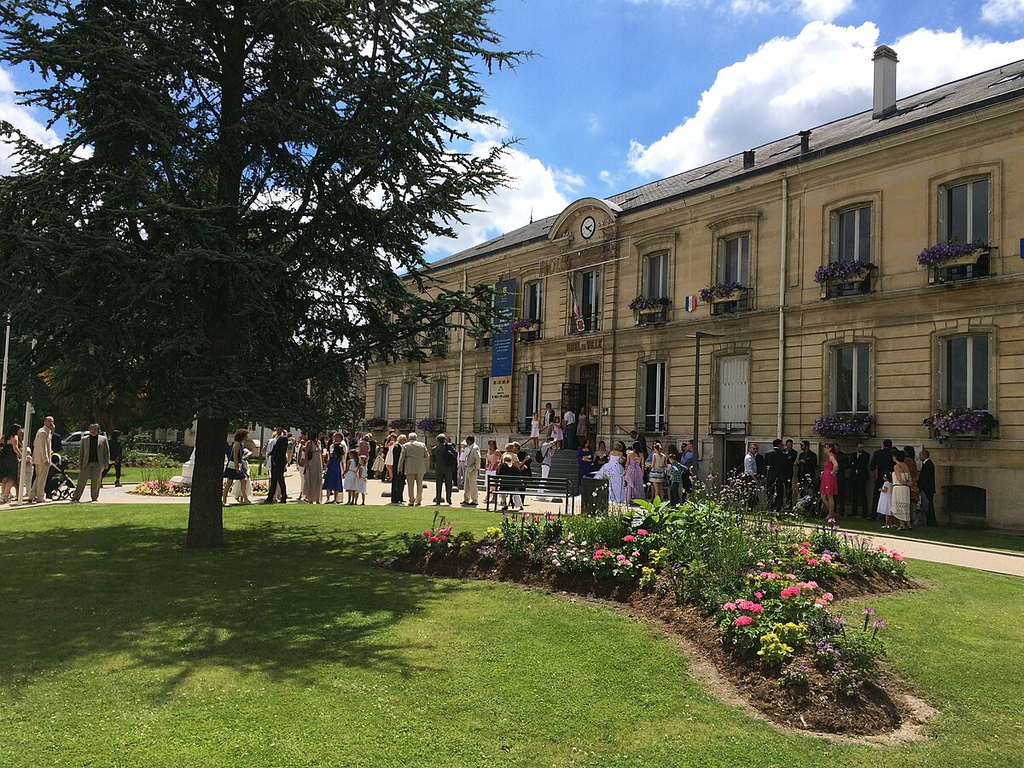

**Mairie de la ville d’Houilles**

## A. SITUATION GLOBALE 2017-2021 (10 pts)

Cette première partie a pour objectif de dresser un portrait d’ensemble du marché immobilier de Houilles sur la période 2017 à 2021. L’analyse s’appuie sur les transactions issues de la base DVF, permettant d’observer les tendances générales du marché local : le volume de ventes, la répartition entre maisons et appartements, ainsi que les niveaux de prix au mètre carré. Ces éléments offriront une vision globale du dynamisme et du positionnement de la commune avant d’aborder l’impact spécifique de la crise du COVID-19.

### A.1 Plus de maisons ou d’appartements

```
Appartement      Maison
       1199        1151
```

```
Appartement      Maison
         51          49
```

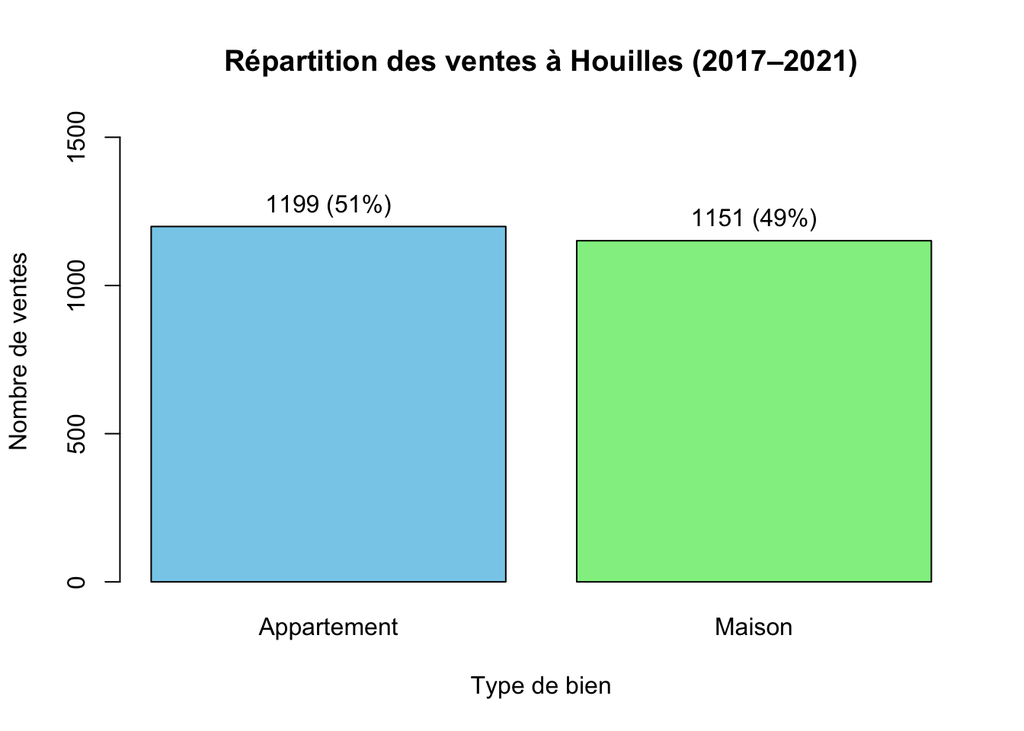

Entre 2017 et 2021, les ventes réalisées à Houilles se répartissent de manière assez équilibrée entre **appartements (1199 ventes, soit environ 51%)** et **maisons (1151 ventes, soit environ 49%**.) Cette répartition témoigne **d’un marché immobilier mixte**, caractéristique d’une commune de proche banlieue où coexistent habitat collectif et pavillonnaire.

Cette première observation permet d’introduire l’analyse des prix au mètre carré

### A.2 : Prix au m² sur l’ensemble de la période

Résumé statistique du prix au m²

```
[1] 4936.2
```

```
[1] 4729.3
```

*Le prix moyen au mètre carré à Houilles s’élève à environ **4936€**, tandis que la médiane, légèrement inférieure **4729€**, traduit un marché où quelques ventes très élevées tirent la moyenne vers le haut.*

```
[1] 1668.1
```

*L’écart-type, d’environ **1668€**, confirme la présence d’une certaine hétérogénéité, avec quelques ventes nettement au-dessus du niveau moyen.*

```
   25%    50%    75%
3867.4 4729.3 5645.4
```

*La moitié des transactions se situent entre **3867€**, (Q1) et **5645€**, (Q3) ce qui montre une dispersion modérée des prix.*

```
   Min. 1st Qu.  Median    Mean 3rd Qu.    Max.
  506.5  3867.4  4729.3  4936.2  5645.4 16884.6
```

*Ce résumé inclut aussi les valeurs extrêmes (**506€ et 16885€/ m²**), qui indiquent la présence de biens très peu cher ou haut de gamme.*

### A.3 : Comparez le prix au m² des maisons et des appartements

```
[1] 4377.6
```

```
[1] 5518.2
```

```
[1] 4285.7
```

```
[1] 5250
```

*En moyenne, **les maisons se vendent à 5518,2€/m²**, contre **4377,6€/m² pour les appartements**.* *La médiane confirme cet écart (**5250€/m² pour les maisons**, contre **4285,7€/m² pour les appartements**).*

Ces résultats indiquent que **les maisons sont globalement plus chères au m²**

```
[1] 1232.1
```

```
[1] 1854.1
```

*L’écart-type plus élevé chez les maisons (**1854€ contre 1232€**) traduit une plus grande diversité des biens.*

```
   25%    50%    75%
3539.7 4285.7 5004.2
```

```
   25%    50%    75%
4375.0 5250.0 6375.7
```

*Les quartiles montrent que la moitié des appartements se vendent entre **3539.7€ et 5004.2€ le mètre carré**, tandis que pour les maisons, la moitié des ventes se situe entre **4375.0€ et 6375.7€**.*

*Cela confirme que, sur l’ensemble du marché à Houilles, les maisons occupent une tranche de prix supérieure à celle des appartements.*

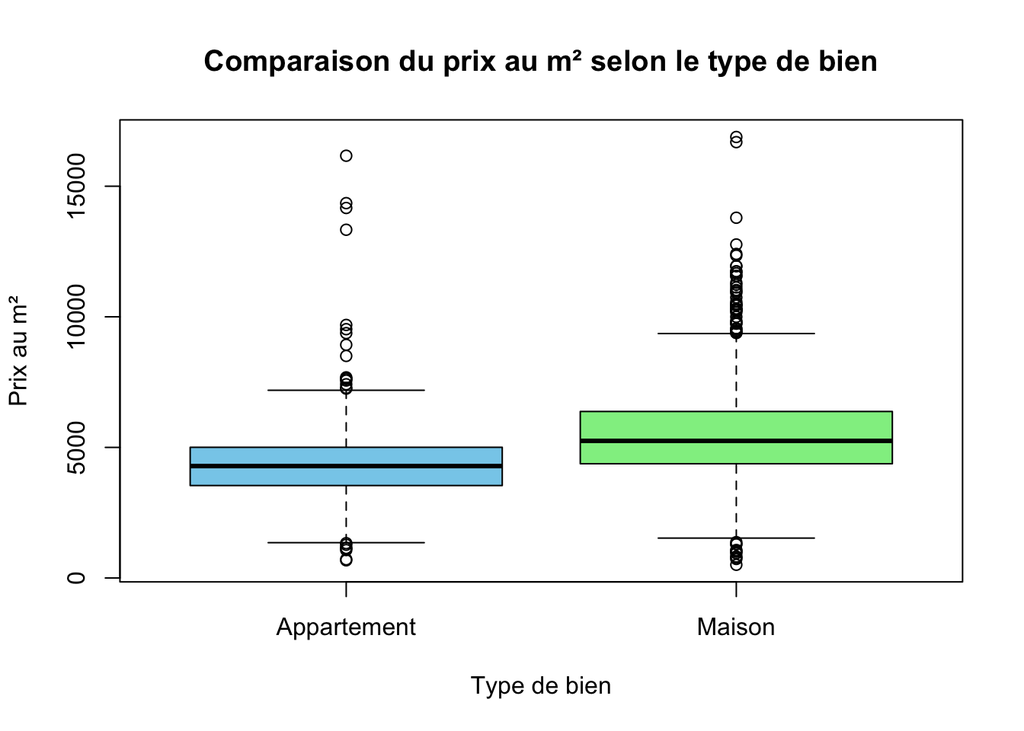

L’analyse du prix au mètre carré révèle une **différence nette entre les appartements et les maisons.** En moyenne, **les maisons se vendent plus cher, autour de 5500€ par m², contre environ 4400€ pour les appartements.** Le boxplot illustre clairement cet écart: la boîte des maisons, située plus haut, montre une **variabilité plus forte des prix, avec plusieurs valeurs exceptionnelles dépassant les 10000€.** Ces écarts traduisent la présence de biens haut de gamme ou atypiques, confirmant que le marché a Houilles reste marqué par une grande **hétérogénéité.**

### A.4 Votre commune est-elle riche ou pauvre

```
[1] 4729.3
```

```
[1] 3878.8
```

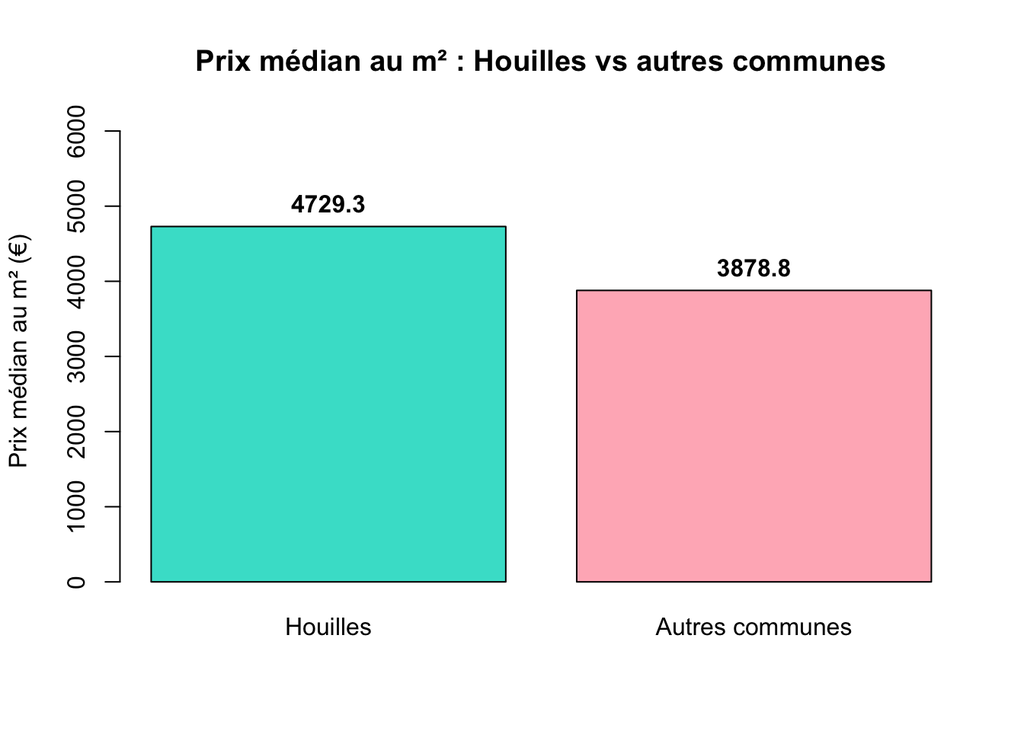

La médiane du prix au m² à Houilles atteint **4729€**, contre **3879€** dans les autres communes étudiées.

Cela montre que **Houilles présente un marché plus cher que la moyenne**, signe d’une commune plutôt aisée

### A.5 Autres remarques (Bonus : +1 pt)

```
       Appartement Maison
  2017         255    232
  2018         252    239
  2019         262    259
  2020         233    213
  2021         197    208
```

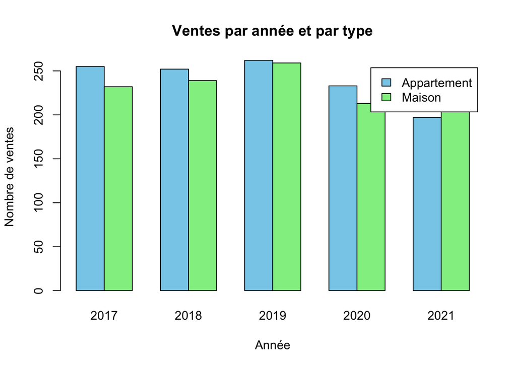

```
[1] "Baisse 2017 → 2021 : 16.8 %"
```

Le graphique en barres met en évidence une **répartition stable** des ventes entre maisons et appartements sur la période 2017–2021, avec des volumes comparables chaque année.

On observe toutefois une légère baisse du total des transactions, passant d’environ 490 ventes en 2017 à 405 en 2021, soit une diminution d’environ 17%.

Il est donc pertinent d’examiner plus en détail l’impact de cette crise sur l’évolution des prix au mètre carré et des volumes de ventes, afin de déterminer si les maisons et les appartements ont été affectés de manière similaire.

## B. IMPACT DE LA CRISE DU COVID EN 2020-21 (6 pts)

```
       Appartement Maison
  2017         255    232
  2018         252    239
  2019         262    259
  2020         233    213
  2021         197    208
```

```
[1] "Baisse 2019 → 2020 : 14.4 %"
```

```
[1] "Baisse 2019 → 2021 : 22.3 %"
```

**Entre 2019 et 2020**, le volume total des ventes à Houilles baisse d’environ **14%**, puis d’environ **22% entre 2019 et 2021.**

*Cette baisse nette du nombre de transactions illustre le ralentissement du marché immobilier pendant la période du COVID-19, marqué par les confinements et l’incertitude économique autant coté vendeur que coté acheteurs*

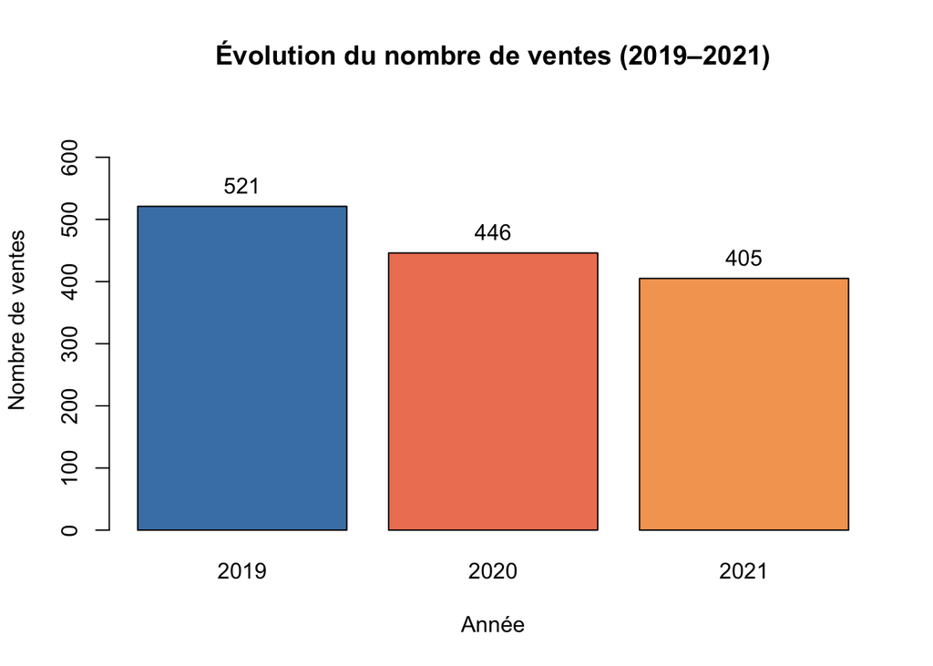

Le graphique confirme une baisse des volumes de ventes après 2019, avec un niveau plus faible en 2020 et 2021.

```
         Type X2019 X2020.2021
1      Global  4741       5023
2 Appartement  4308       4652
3      Maison  5240       5532
```

Le tableau ci-dessus met en évidence une **hausse généralisée des prix médians au m² entre 2019 et 2020–2021**, aussi bien pour les appartements que pour les maisons.

Bien que le nombre de ventes ait diminué pendant la crise sanitaire, **les prix médians ont continué à progresser de 6% à 8% selon le type de bien**.

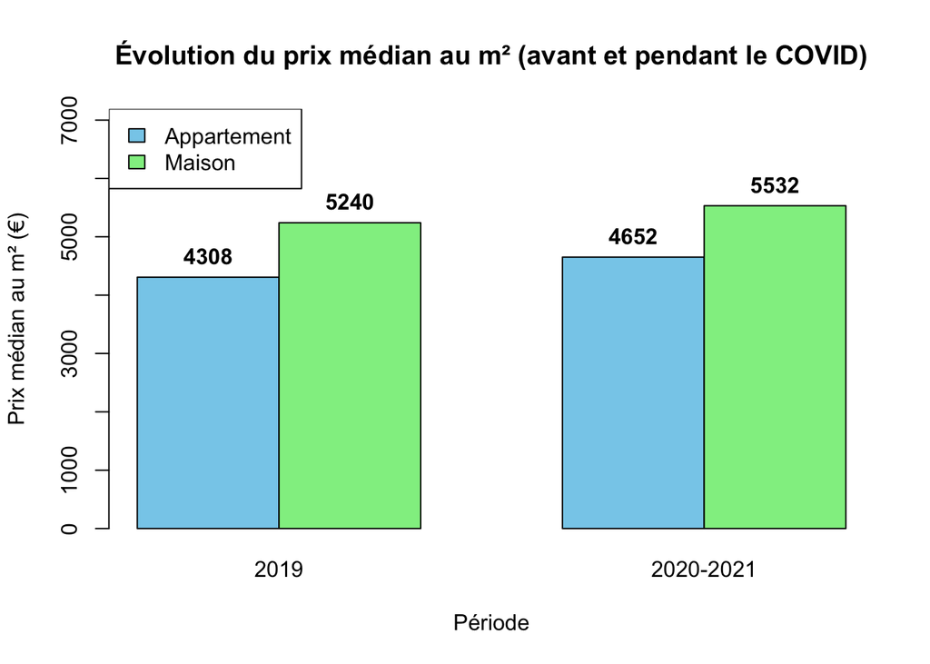

**Les maisons restent plus chères au m² que les appartements avant comme pendant la crise.**

## CONCLUSION (2 pt)

**L’analyse du marché immobilier à Houilles met en évidence un secteur dynamique et équilibré, partagé presque à parts égales entre maisons et appartements.Les prix y demeurent élevés, avec un niveau médian d’environ 4700€/m², supérieur à celui observé dans les autres communes de la base.**

**Malgré la baisse du nombre de transactions observée entre 2019 et 2021, notamment durant la période du COVID-19, le niveau des prix est resté stable, voir en légère hausse, confirmant la solidité et l’attractivité du marché à Houilles.**